# Final_project

Zirui Liu

5/3/2018

## Introduction

On June 14, 2014, LeBron James opted out of his contract and later that month he decided to return his home team, Cleveland Cavaliars. The team, Cleveland Cavaliars had compiled a league worst 97-215 records in the past four seasons before LeBron’s return In 2016, after 52 years without a championship in a major sport, Cleveland wears the crown, bestowed by basketball’s forever king. Toronto Raptors leading by NBA All Stars: DeMar DeRozan and Kyle Lowry becomes one of the strongest team in the east conference. However, they have never beated Cleveland Cavaliars in the playoffs after LeBron James returned. Although, Toronto Raptors is the No.1 seed in east conference this year, Cleveland leads 3-0 as I am writing this.

## Data

The data I use for this project is from NBA Advanced Stats:(https://stats.nba.com/) and tweets mentioning this two teams from twitter api. From the data I have, I want to visulize the contribution LeBron James to the team and analyze the tweets meesage about the game.

Helper function

```r
#Custom functions to simplify code
getWordFreq <- function(file, freqMin, name) {
  text <- readLines(file)
  text_df <- data_frame(line = 1:length(text), text = text )
  text_df <- text_df %>%
    unnest_tokens(word, text) %>%
    count(word, sort = TRUE) %>%
    filter(n > freqMin) %>%
    anti_join(stop_words, by = "word") %>%
    mutate(word = reorder(word, n)) %>%
    ggplot(aes(word, n)) +
    geom_col() +
    xlab(NULL) +
    ggtitle(name) +
    coord_flip()
}


getTidyTibble <- function(file) {
  text <- readLines(file)
  df <- data_frame(line = 1:length(text), text = text)
  df <- df %>%
    unnest_tokens(word, text) %>%
    anti_join(stop_words)
  return(df)
}
```

# Team scores comparison between Cleveland Cavaliers and Toronto Raptors

Red – Raptors Blue – Cavaliers

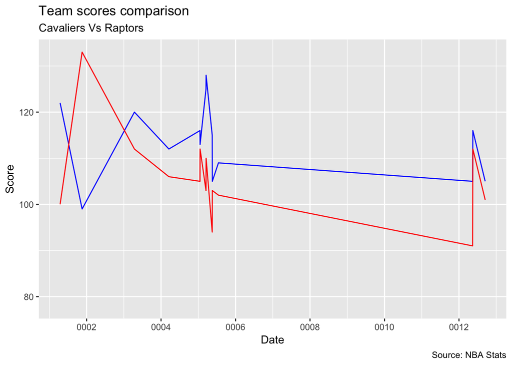

```r
data_total <- read.csv("cavs_raptors.csv")
data_total <- as.tibble(data_total)
data_total$DATE <- as.Date(data_total$DATE)
daily <- filter(data_total)
ggplot(daily, aes(x = DATE)) +
  geom_line(aes(y = CLE.PTS), colour="blue", size = 0.5) +
  geom_line(aes(y = Raptors.PTS), colour="red", size = 0.5) +
  labs(subtitle="Cavaliers Vs Raptors",
       y="Score",
       x="Date",
       title="Team scores comparison",
       caption = "Source: NBA Stats")
```

As we can see from the graph, the blue line represents Cavaliers’ score and the red line represents Raptors’ score. The data I chose is after LeBron James returned to Cleveland Cavaliers. We can easily see that even though there are some very close games, most of the time, Clevelead beat Toronto.

# Points LeBron James contributes to the total score

Red – Points LBJ scores

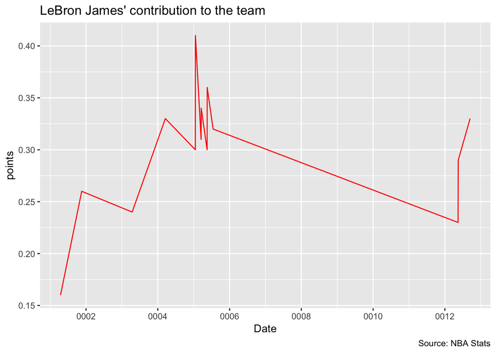

```r
data_total <- read.csv("cavs_raptors.csv")
data_total <- as.tibble(data_total)
data_total$DATE <- as.Date(data_total$DATE)
daily <- filter(data_total)
ggplot(daily, aes(x = DATE)) +
  geom_line(aes(y = LBJ_PCG), colour="red", size = 0.5) +
  labs(y="points",
       x="Date",
       title="LeBron James' contribution to the team",
       caption = "Source: NBA Stats")
```

The above graph solely considers the contribution of points to the team not including assists, rebounds and leadership. Since, a basketball team usually rotate 8 players for each game, we can easily see that the contribution of average 30% of points is very significant. For some game, LeBron James even contributed more than 40% of the total score.

```r
consumer_key <- "VovdJylrMlUqYcKuCC7ey9SSZ"
consumer_secret <- "bMBSQpFdBqQ77qizilP8ymBon0OFgXoMW2XhhcJxAth9VUU2Iu"
access_token <- "992102228239503360-R2BB3ODGfT99DzWvP2XxI2LRSnVvJLs"
access_secret <- "e8npyQ749tiL5ZJF4O3B4idAWiCDCf4Z935e55Tew5HWh"
setup_twitter_oauth(consumer_key, consumer_secret, access_token, access_secret)
```

```
## [1] "Using direct authentication"
```

```r
# Get tweets about Cleveland Cavaliers
tw = twitteR::searchTwitter('cavs', n = 5000, since = '2018-5-03', retryOnRateLimit = 4)
cavs = twitteR::twListToDF(tw)
clean_cavs <- as_tibble(cavs)
clean_cavs <- subset(clean_cavs, select = c(1))
write.csv(clean_cavs, file = "cavs.csv")

# Get tweets about Toronto Raptors
tw = twitteR::searchTwitter('Raptors', n = 5000, since = '2018-5-03', retryOnRateLimit = 4)
raptors = twitteR::twListToDF(tw)
clean_raptors <- as_tibble(raptors)
clean_raptors <- subset(clean_raptors, select = c(1))
write.csv(clean_raptors, file = "raptors.csv")


# Get tweets about Cleveland Cavaliers after game
tw = twitteR::searchTwitter('cavs', n = 5000, since = '2018-5-04', retryOnRateLimit = 4)
cavs = twitteR::twListToDF(tw)
clean_cavs <- as_tibble(cavs)
clean_cavs <- subset(clean_cavs, select = c(1))
write.csv(clean_cavs, file = "after_cavs.csv")

# Get tweets about Toronto Raptors after game
tw = twitteR::searchTwitter('Raptors', n = 5000, since = '2018-5-04', retryOnRateLimit = 4)
```

```
## [1] "Rate limited .... blocking for a minute and retrying up to 3 times ..."
## [1] "Rate limited .... blocking for a minute and retrying up to 2 times ..."
## [1] "Rate limited .... blocking for a minute and retrying up to 1 times ..."
## [1] "Rate limited .... blocking for a minute and retrying up to 0 times ..."
```

```r
raptors = twitteR::twListToDF(tw)
clean_raptors <- as_tibble(raptors)
clean_raptors <- subset(clean_raptors, select = c(1))
write.csv(clean_raptors, file = "after_raptors.csv")
```

I used Twitter api to extract tweets mentioning “cavs” and “raptors” before and after May 3rd game. Also, I stored them into different csv file.

# read csv file and clean data

```r
cavs = readLines("cavs.csv")
write.table(cavs,"cavs.txt",sep="\t",row.names=FALSE)

raptors = readLines("raptors.csv")
write.table(raptors,"raptors.txt",sep="\t",row.names=FALSE)

cavs = readLines("after_cavs.csv")
write.table(cavs,"after_cavs.txt",sep="\t",row.names=FALSE)

raptors = readLines("after_raptors.csv")
write.table(raptors,"after_raptors.txt",sep="\t",row.names=FALSE)
```

# Get frequencey of words in tweets before May 3rd game

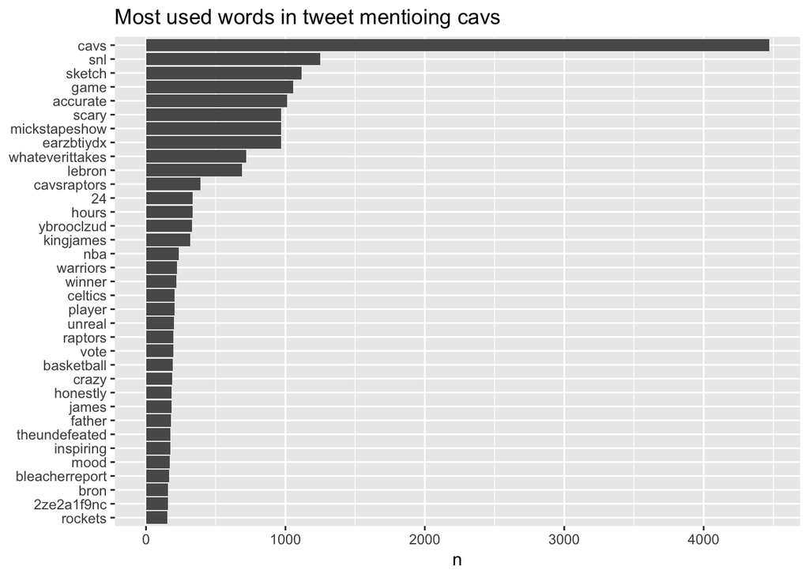

```r
cavs <-  getWordFreq('cavs.txt', 150, 'Most used words in tweet mentioing cavs')
raptors <- getWordFreq('raptors.txt', 200, 'Most used words in tweets mentioing raptors')

cavs
```

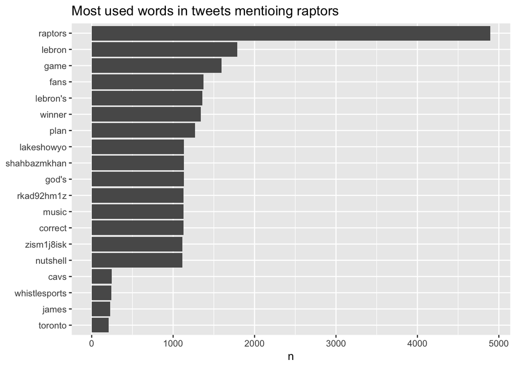

```r
raptors
```

# Get frequencey of words in tweets after May 3rd game

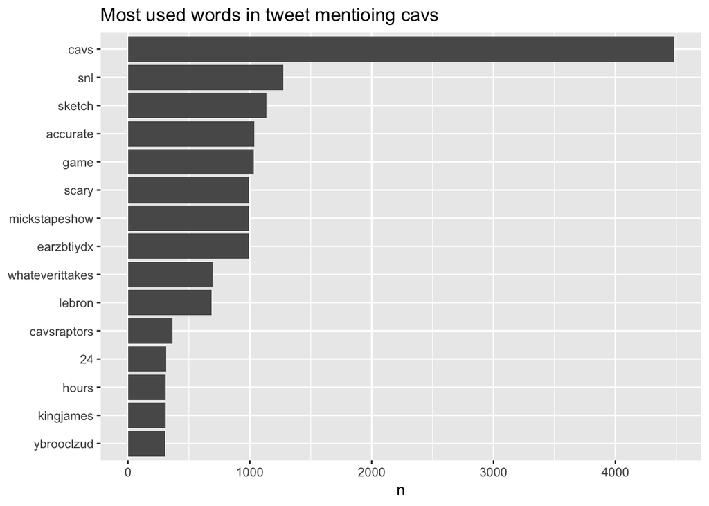

```r
cavs <-  getWordFreq('after_cavs.txt', 250, 'Most used words in tweet mentioing cavs')
raptors <- getWordFreq('after_raptors.txt', 250, 'Most used words in tweets mentioing raptors')

cavs
```

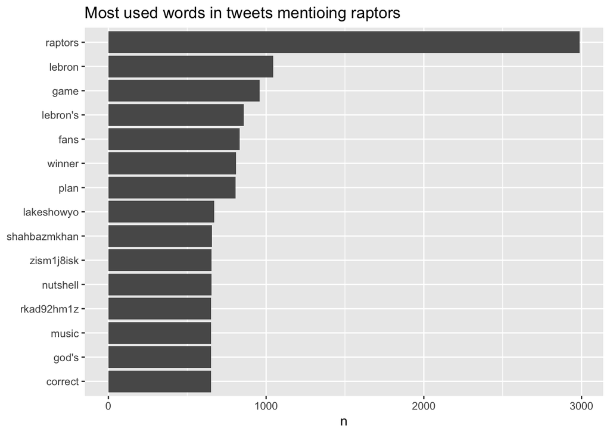

```r
raptors
```

As we can see from the grpah, fans from both teams mentioning the names of two teams the most. It is also interesting to see that fans from both teams mentioning LeBron James’ name a lot and this may be caused by the amazing performance LBJ has in this series. In the last 3 games, LBJ made the cluch shot twice.

# Word cloud before May 3rd game

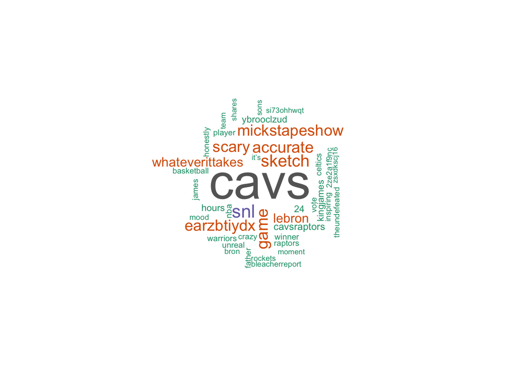

```r
library(wordcloud)

cavs_df <- getTidyTibble('cavs.txt')
raptors_df <- getTidyTibble('raptors.txt')
cavsCloud <- cavs_df %>%
  count(word, sort = TRUE)
raptorsCloud <- raptors_df %>%
  count(word, sort = TRUE)



wordcloud(words = cavsCloud$word, freq = cavsCloud$n, min.freq = 125,
          max.words=300, random.order=FALSE, rot.per=0.35,
          colors=brewer.pal(8, "Dark2"))
```

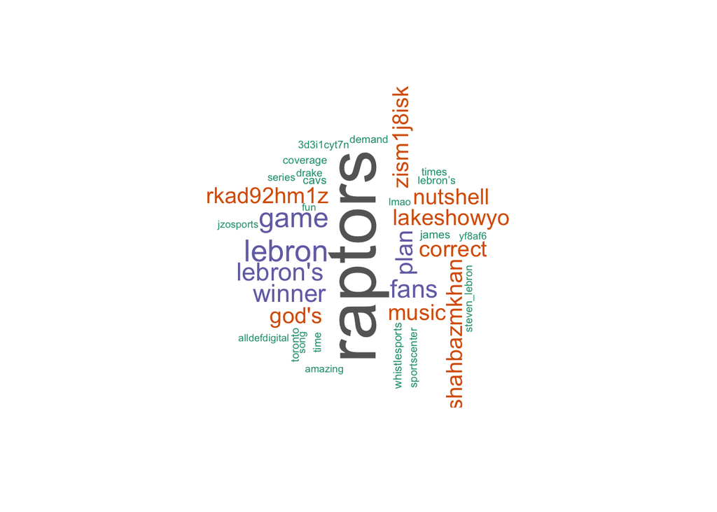

```r
wordcloud(words = raptorsCloud$word, freq = raptorsCloud$n, min.freq = 125,
          max.words=300, random.order=FALSE, rot.per=0.35,
          colors=brewer.pal(8, "Dark2"))
```

# Word cloud after May 3rd game

```r
after_cavs_df <- getTidyTibble('after_cavs.txt')
after_raptors_df <- getTidyTibble('after_raptors.txt')
```

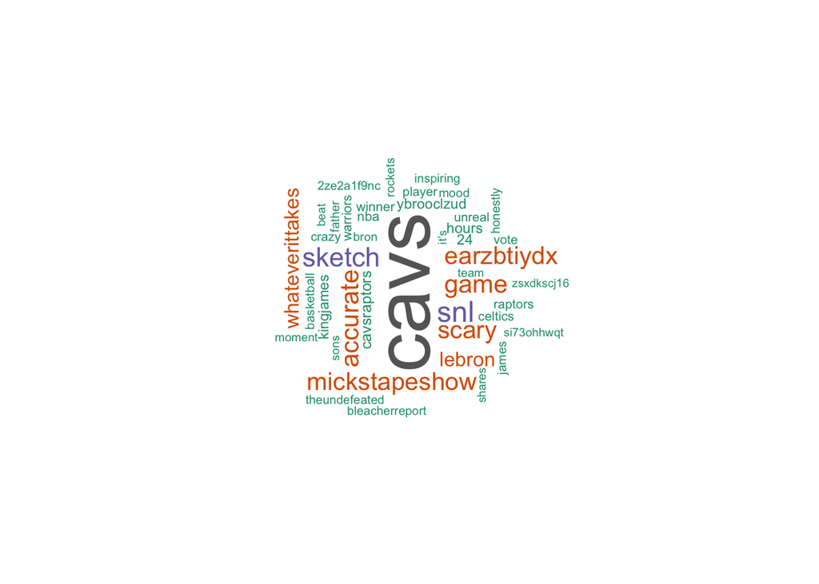

```r
after_cavsCloud <- after_cavs_df %>%
  count(word, sort = TRUE)
after_raptorsCloud <- after_raptors_df %>%
  count(word, sort = TRUE)



wordcloud(words = after_cavsCloud$word, freq = after_cavsCloud$n, min.freq = 125,
          max.words=300, random.order=FALSE, rot.per=0.35,
          colors=brewer.pal(8, "Dark2"))
```

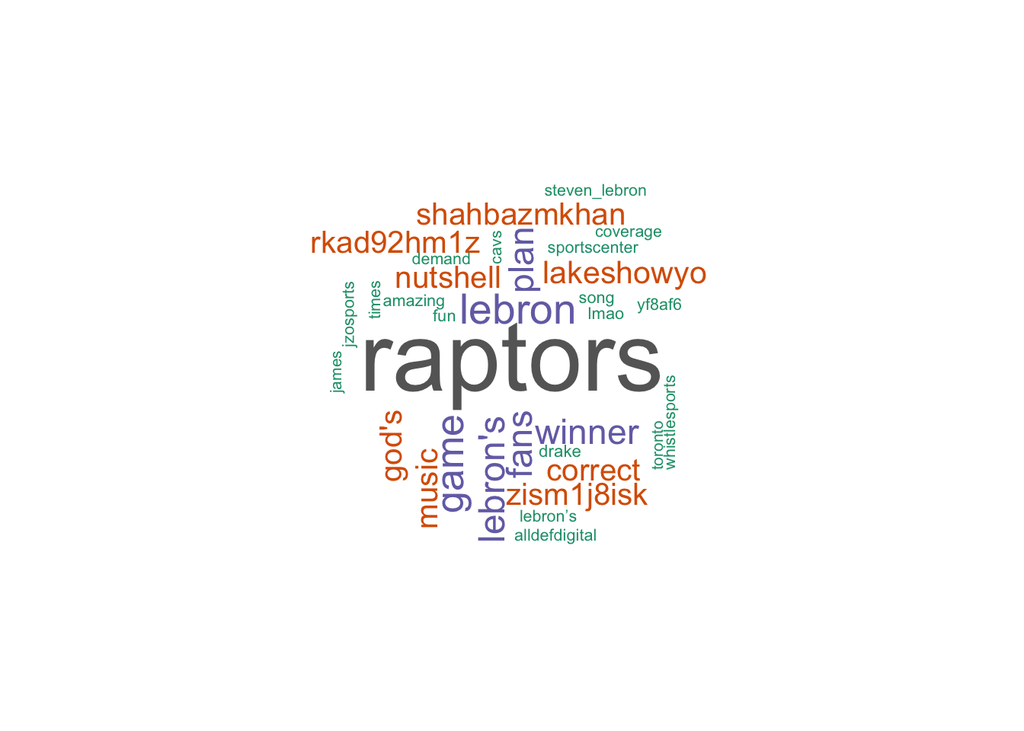

```r
wordcloud(words = after_raptorsCloud$word, freq = after_raptorsCloud$n, min.freq = 125,
          max.words=300, random.order=FALSE, rot.per=0.35,
          colors=brewer.pal(8, "Dark2"))
```

# Create sentiments based on tweets

```r
cavs <- read.delim("/Users/mac/Desktop/GitHub/MA415-HW/Final\ project/cavs.txt", header=FALSE)
raptors <- read.delim("/Users/mac/Desktop/GitHub/MA415-HW/Final\ project/raptors.txt", header = FALSE)
after_cavs <- read.delim("/Users/mac/Desktop/GitHub/MA415-HW/Final\ project/after_cavs.txt", header=FALSE)
after_raptors <- read.delim("/Users/mac/Desktop/GitHub/MA415-HW/Final\ project/after_raptors.txt", header = FALSE)
# The directory address of speech text might be different.

# Read text
tidy_cavs<- data_frame(paragraph = 149, text = as.character(cavs$V1)) %>%
  unnest_tokens(word, text)
tidy_raptors <- data_frame(paragraph = 112, text= as.character(raptors$V1)) %>%
  unnest_tokens(word, text)
tidy_after_cavs<- data_frame(paragraph = 149, text = as.character(after_cavs$V1)) %>%
  unnest_tokens(word, text)
tidy_after_raptors <- data_frame(paragraph = 112, text= as.character(after_raptors$V1)) %>%
  unnest_tokens(word, text)

# cavs tweets before game
cavs_sentiment <- tidy_cavs %>%
  inner_join(get_sentiments("bing")) %>%
  count(word, sentiment, index = paragraph %/% 2) %>%
  spread(sentiment, n, fill = 0) %>%
  mutate(sentiment = positive-negative)
# cavs tweets after game
cavs_after_sentiment <- tidy_after_cavs %>%
  inner_join(get_sentiments("bing")) %>%
  count(word, sentiment, index = paragraph %/% 2) %>%
  spread(sentiment, n, fill = 0) %>%
  mutate(sentiment = positive-negative)
# raptors tweets before game
raptors_sentiment <- tidy_raptors %>%
  inner_join(get_sentiments("bing")) %>%
  count(word, sentiment, index = paragraph %/% 3) %>%
  spread(sentiment, n, fill = 0) %>%
  mutate(sentiment = positive-negative)
# raptors tweets after game
raptors_after_sentiment <- tidy_after_raptors %>%
  inner_join(get_sentiments("bing")) %>%
  count(word, sentiment, index = paragraph %/% 3) %>%
  spread(sentiment, n, fill = 0) %>%
  mutate(sentiment = positive-negative)
```

## Positive/negative words for Cavs tweets before May 3rd game

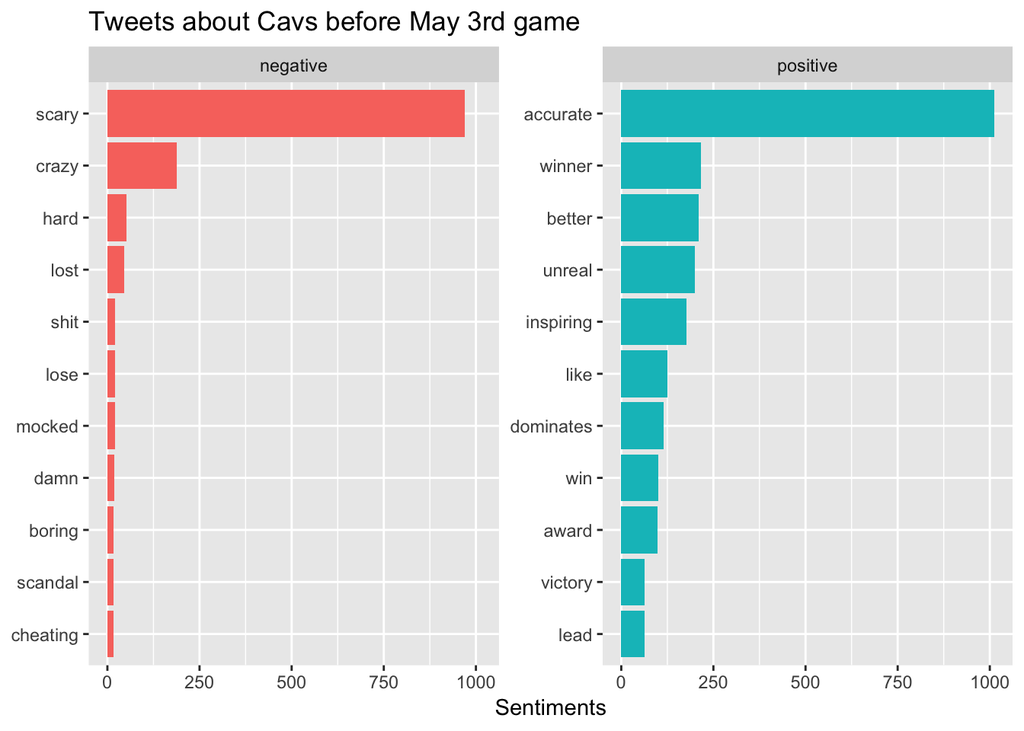

```r
cavs_word_counts <- tidy_cavs %>%
  inner_join(get_sentiments("bing")) %>%
  count(word, sentiment, sort = TRUE)

cavs_word_counts %>%
  group_by(sentiment) %>%
  top_n(10) %>%
  ungroup() %>%
  mutate(word = reorder(word, n)) %>%
  ggplot(aes(word, n, fill = sentiment)) +
  geom_col(show.legend = FALSE) +
  facet_wrap(~sentiment, scales = "free_y") +
  labs(y = "Sentiments",
       x = NULL) +
  ggtitle("Tweets about Cavs before May 3rd game") +
  coord_flip()
```

## Positive/negative words for Raptors tweets before May 3rd game

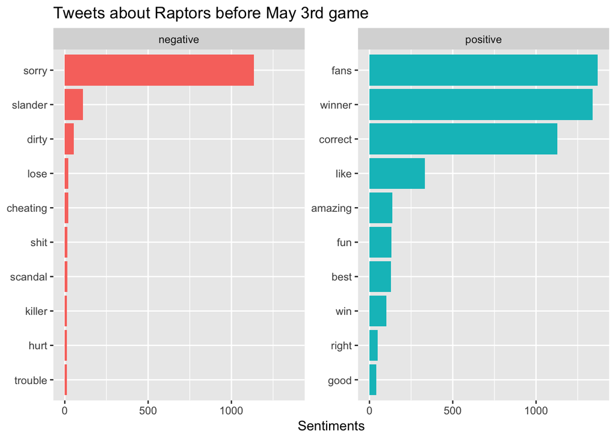

```r
raptors_word_counts <- tidy_raptors %>%
  inner_join(get_sentiments("bing")) %>%
  count(word, sentiment, sort = TRUE)

raptors_word_counts %>%
  group_by(sentiment) %>%
  top_n(10) %>%
  ungroup() %>%
  mutate(word = reorder(word, n)) %>%
  ggplot(aes(word, n, fill = sentiment)) +
  geom_col(show.legend = FALSE) +
  facet_wrap(~sentiment, scales = "free_y") +
  labs(y = "Sentiments",
       x = NULL) +
  ggtitle("Tweets about Raptors before May 3rd game") +
  coord_flip()
```

## Positive/negative words for Cavs tweets after May 3rd game

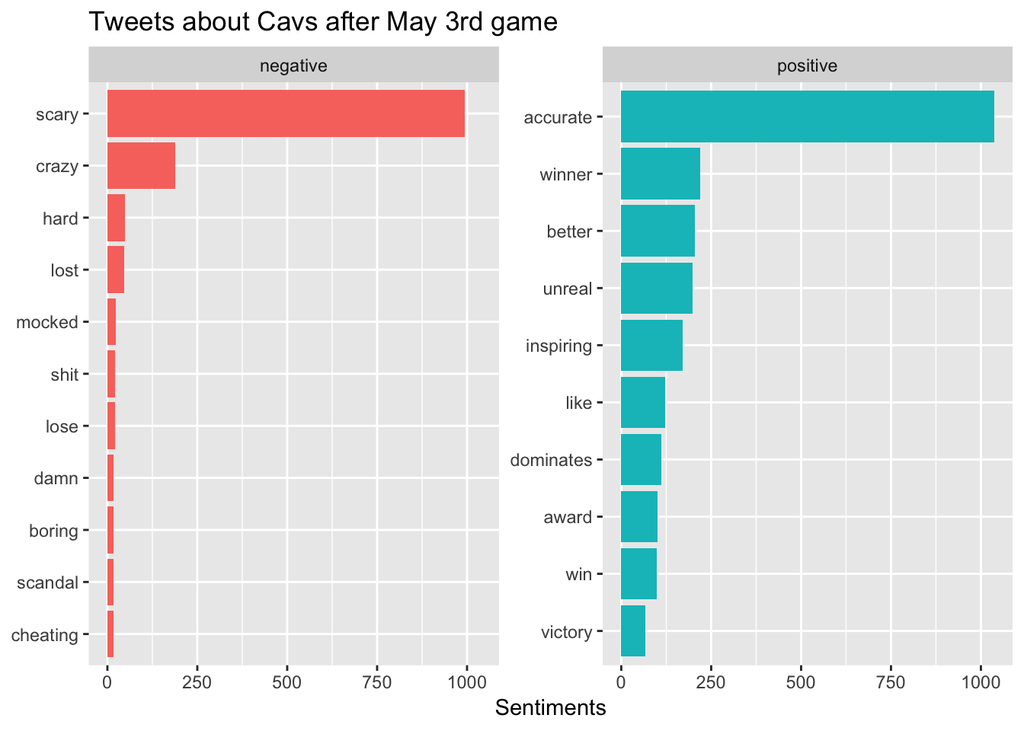

```r
cavs_word_counts <- tidy_after_cavs %>%
  inner_join(get_sentiments("bing")) %>%
  count(word, sentiment, sort = TRUE)

cavs_word_counts %>%
  group_by(sentiment) %>%
  top_n(10) %>%
  ungroup() %>%
  mutate(word = reorder(word, n)) %>%
  ggplot(aes(word, n, fill = sentiment)) +
  geom_col(show.legend = FALSE) +
  facet_wrap(~sentiment, scales = "free_y") +
  labs(y = "Sentiments",
       x = NULL) +
  ggtitle("Tweets about Cavs after May 3rd game") +
  coord_flip()
```

## Positive/negative words for Raptors tweets after May 3rd game

[figure not shown]

```r
raptors_word_counts <- tidy_after_raptors %>%
  inner_join(get_sentiments("bing")) %>%
  count(word, sentiment, sort = TRUE)

raptors_word_counts %>%
  group_by(sentiment) %>%
  top_n(10) %>%
  ungroup() %>%
  mutate(word = reorder(word, n)) %>%
  ggplot(aes(word, n, fill = sentiment)) +
  geom_col(show.legend = FALSE) +
  facet_wrap(~sentiment, scales = "free_y") +
  labs(y = "Sentiments",
       x = NULL) +
  ggtitle("Tweets about Raptors before May 3rd game") +
  coord_flip()
```

## More sentiment analysis for CAVS

```r
# Sentiment analysis with nrc
nrc_joy <- get_sentiments("nrc") %>%
  filter(sentiment == "joy")
nrc_anger <- get_sentiments("nrc") %>%
  filter(sentiment == "anger")
nrc_anticipation <- get_sentiments("nrc") %>%
  filter(sentiment == "anticipation")
nrc_sadness <- get_sentiments("nrc") %>%
  filter(sentiment == "sadness")

# Trump sentiment analysis with nrc
cavs_joy <- tidy_cavs %>%
  inner_join(nrc_joy) %>%
  count(word, sort = TRUE) %>%
  filter(n > 10) %>%
  mutate(word = reorder(word, n))
cavs_anger <- tidy_cavs %>%
  inner_join(nrc_anger) %>%
  count(word, sort = TRUE) %>%
  filter(n > 10) %>%
  mutate(word = reorder(word, n))
cavs_anticipation <- tidy_cavs %>%
  inner_join(nrc_anticipation) %>%
  count(word, sort = TRUE) %>%
  filter(n > 10) %>%
  mutate(word = reorder(word, n))
cavs_sadness <- tidy_cavs %>%
  inner_join(nrc_sadness) %>%
  count(word, sort = TRUE) %>%
  filter(n > 10) %>%
  mutate(word = reorder(word, n))
```

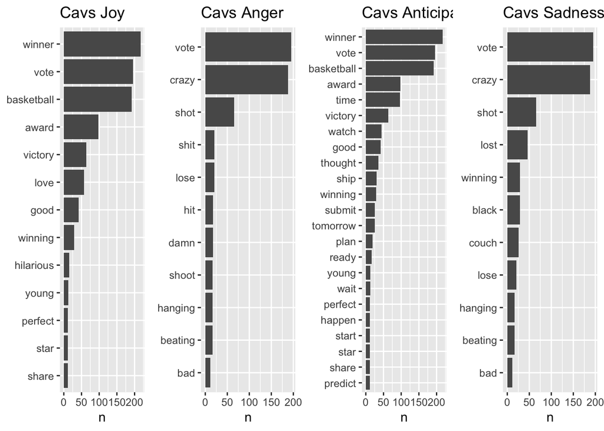

```r
gridExtra::grid.arrange(
  ggplot(cavs_joy, aes(word, n)) +
    geom_col() +
    xlab(NULL) +
    coord_flip() +
    ggtitle("Cavs Joy"),
  ggplot(cavs_anger, aes(word, n)) +
    geom_col() +
    xlab(NULL) +
    coord_flip() +
    ggtitle("Cavs Anger"),
  ggplot(cavs_anticipation, aes(word, n)) +
    geom_col() +
    xlab(NULL) +
    coord_flip() +
    ggtitle("Cavs Anticipation"),
  ggplot(cavs_sadness, aes(word, n)) +
    geom_col() +
    xlab(NULL) +
    coord_flip() +
    ggtitle("Cavs Sadness"),
  nrow=1
)
```

## More sentiment analysis for Raptors

```r
# Sentiment analysis with nrc
nrc_joy <- get_sentiments("nrc") %>%
  filter(sentiment == "joy")
nrc_anger <- get_sentiments("nrc") %>%
  filter(sentiment == "anger")
nrc_anticipation <- get_sentiments("nrc") %>%
  filter(sentiment == "anticipation")
nrc_sadness <- get_sentiments("nrc") %>%
  filter(sentiment == "sadness")

# Trump sentiment analysis with nrc
raptors_joy <- tidy_raptors %>%
  inner_join(nrc_joy) %>%
  count(word, sort = TRUE) %>%
  filter(n > 10) %>%
  mutate(word = reorder(word, n))
raptors_anger <- tidy_raptors %>%
  inner_join(nrc_anger) %>%
  count(word, sort = TRUE) %>%
  filter(n > 10) %>%
  mutate(word = reorder(word, n))
raptors_anticipation <- tidy_raptors %>%
  inner_join(nrc_anticipation) %>%
  count(word, sort = TRUE) %>%
  filter(n > 10) %>%
  mutate(word = reorder(word, n))
raptors_sadness <- tidy_raptors %>%
  inner_join(nrc_sadness) %>%
  count(word, sort = TRUE) %>%
  filter(n > 10) %>%
  mutate(word = reorder(word, n))
```

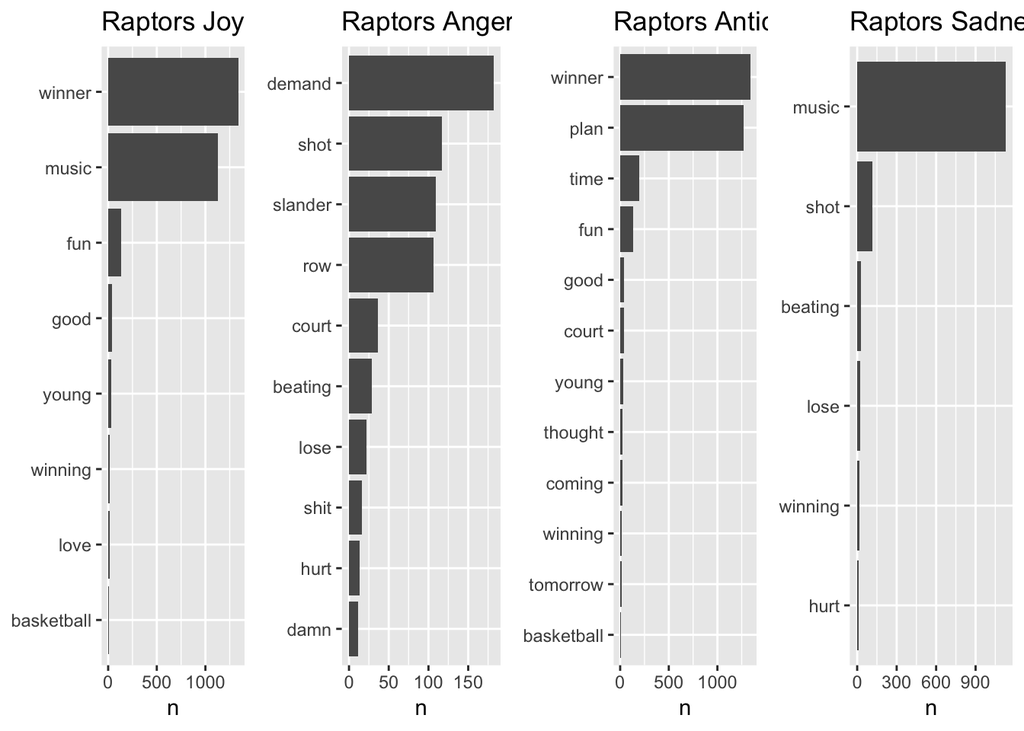

```r
gridExtra::grid.arrange(
  ggplot(raptors_joy, aes(word, n)) +
    geom_col() +
    xlab(NULL) +
    coord_flip() +
    ggtitle("Raptors Joy"),
  ggplot(raptors_anger, aes(word, n)) +
    geom_col() +
    xlab(NULL) +
    coord_flip() +
    ggtitle("Raptors Anger"),
  ggplot(raptors_anticipation, aes(word, n)) +
    geom_col() +
    xlab(NULL) +
    coord_flip() +
    ggtitle("Raptors Anticipation"),
  ggplot(raptors_sadness, aes(word, n)) +
    geom_col() +
    xlab(NULL) +
    coord_flip() +
    ggtitle("Raptors Sadness"),
  nrow=1
)
```